# 1.5 Time Invariance

- 1.5.1 New Train/Test Split
  - Figure 1. Number of Inspections Conducted By Month
  - Figure 2. Proportion of All Inspections Conducted by Month
  - Table 1. Summary of Violation Codes in Train and Test
  - Table 2. Frequency Ranking of Violation Codes in Train and Test
- 1.5.2 Frequency of Violations by Month
  - Figure 3. Proportion of All Inspections with Critical Found by Month
  - Figure 4. Proportion of Monthly Inspections with Critical Found by Month
  - Figure 5. Number of Violations Issued by Month
  - Figure 6. Proportion of All Violations with Violation Code by Month
  - Figure 7. Proportion of Monthly Violations with Violation Code by Month
  - Figure 8. Proportion of Monthly Violations with Violation Code by Month (Different Axes)
- 1.5.3 City Model Scheduling
  - Table 3. Confusion Matrix for City Model Predictions on Test Set
  - Figure 9. City Model Performance According to City Metrics on Test Set
  - Figure 10. Number of Inspections Conducted by Month
  - Figure 11. Proportion of All Inspections with Critical Found by Month
  - Figure 12. Proportion of Monthly Inspections with Critical Found by Month
  - Figure 13. Number of Violations Issued by Month
  - Figure 14. Proportion of All Violations with Violation Code by Month
  - Figure 15. Proportion of Monthly Violations with Violation Code by Month (Different Axes)

Code hiding script from [Damian Kao](http://blog.nextgenetics.net/?e=102).

```python
from IPython.display import HTML
HTML('''<script>
code_show=true;
function code_toggle() {
 if (code_show){
 $('div.input').hide();
 } else {
 $('div.input').show();
 }
 code_show = !code_show
}
$( document ).ready(code_toggle);
</script>
Code hidden for easier reading: <a href="javascript:code_toggle()">toggle on/off.</a>''')
```

Code hidden for easier reading: toggle on/off.

```python
import pandas as pd
import numpy as np
import scipy.stats as stat
%matplotlib inline
import matplotlib.pyplot as plt
import seaborn as sns
import pickle
import math
```

```python
from research.strings import TARGET, INSPECTION_ID, DATE
from research.utils import get_crit_mat
```

## 1.5.1 New Train/Test Split

Ensure that both train and test sets have a full year of data, covering each month.

```python
# Load data
raw = pd.read_csv("data/inspections.csv")
print("Read: {} records".format(len(raw)))
# Extract date information
all_df = pd.DataFrame(raw.copy())
all_df["month"] = pd.DatetimeIndex(raw["inspection_date"]).month.values
all_df["year"] = pd.DatetimeIndex(raw["inspection_date"]).year.values
all_df["week"] = pd.DatetimeIndex(raw["inspection_date"]).week.values
all_df["date_str"] = raw["inspection_date"].astype(np.datetime64).apply(lambda dt: dt.strftime("%Y-%m-%d"))
# Extract critical violation codes
crit_mat = get_crit_mat(all_df)
VIOLATION_LABELS = list(crit_mat.columns)
N_VIOLS = len(VIOLATION_LABELS)
# Merge on inspection ID
crit_mat[INSPECTION_ID] = all_df[INSPECTION_ID]
merged = all_df.set_index(INSPECTION_ID).join(crit_mat.set_index(INSPECTION_ID))
merged = merged.reset_index()
print("Merged: {} records".format(len(merged)))
print()
# Make new train/test split
START_DATE = 15431 # April 1st, 2012 (inclusive)
MID_DATE = 15796 # April 1st, 2013 (inclusive for test set)
END_DATE = 16160 # March 31st, 2014 (inclusive)
MONTHS = list(range(1, 13))
MONTH_TICKS = list(range(12))
MONTH_LABELS = ["Jan", "Feb", "Mar", "Apr", "May", "Jun", "Jul", "Aug", "Sep", "Oct", "Nov", "Dec"]
df = merged.query("{col} >= {start} and {col} <= {end}".format(col=DATE, start=START_DATE, end=END_DATE))
df_train = df.query("{col} < {mid}".format(col=DATE, mid=MID_DATE))
df_test = df.query("{col} >= {mid}".format(col=DATE, mid=MID_DATE))
print("Train: {} to {}".format(df_train["date_str"].min(), df_train["date_str"].max()))
print("Test:  {} to {}".format(df_test["date_str"].min(), df_test["date_str"].max()))
print()
print("Date Range Contains: {} records".format(len(df)))
print()
print("Train: N = {0}, P(critical) = {1:.3f}".format(len(df_train), df_train[TARGET].mean()))
print("Test:  N = {0}, P(critical) = {1:.3f}".format(len(df_test), df_test[TARGET].mean()))
```

```
Read: 18712 records
Merged: 18712 records

Train: 2012-04-02 to 2013-03-29
Test:  2013-04-01 to 2014-03-31

Date Range Contains: 13642 records

Train: N = 5788, P(critical) = 0.138
Test:  N = 7854, P(critical) = 0.146
```

```python
def group_crits_month(df_data):
    # Calculate proportion of inspections with critical found / all inspections per month
    n_insps_month = df_data.groupby(by="month")["month"].count().values
    n_found_month = df_data.groupby(by="month")[TARGET].sum().values
    p_found_month = n_found_month / n_insps_month
    # Calculate proportion of each violation / all instances of critical violations per month
    n_viols_month = df_data.groupby(by="month")[VIOLATION_LABELS].sum().values
    n_crits_month = n_viols_month.sum(axis=1)
    n_totals_month = np.vstack([n_crits_month for v in VIOLATION_LABELS]).T
    p_viols_month = n_viols_month / n_totals_month
    res_found = (n_insps_month, n_found_month, p_found_month)
    res_viols = (n_viols_month, n_totals_month, p_viols_month)
    return res_found, res_viols
```

```python
# Group violations by month for train
train_found, train_viols = group_crits_month(df_train)
n_insps_month_train, n_found_month_train, p_found_month_train = train_found
n_viols_month_train, n_totals_month_train, p_viols_month_train = train_viols
# Group violations by month for test
test_found, test_viols = group_crits_month(df_test)
n_insps_month_test, n_found_month_test, p_found_month_test = test_found
n_viols_month_test, n_totals_month_test, p_viols_month_test = test_viols
```

### Figure 1. Number of Inspections Conducted By Month

- The test set includes a greater total number of inspections, both overall and per month.
- In the train set, most inspections were conducted in March, with January as a close second.
- In the test set, most inspections were conducted in October, with May as a close second.

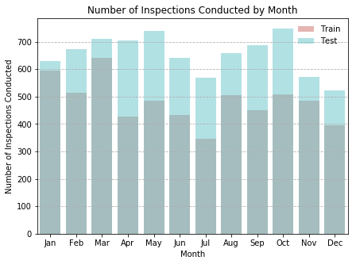

```python
pal = sns.color_palette("hls", 2)
sns.barplot(MONTHS, n_insps_month_train, color=pal[0], alpha=0.5, label="Train")
sns.barplot(MONTHS, n_insps_month_test, color=pal[1], alpha=0.5, label="Test")
plt.xticks(MONTH_TICKS, MONTH_LABELS)
plt.grid(axis="y", linestyle="--")
plt.xlabel("Month")
plt.ylabel("Number of Inspections Conducted")
plt.title("Number of Inspections Conducted by Month")
plt.gcf().set_size_inches(7, 5)
plt.legend(frameon=False)
plt.show()
```

### Figure 2. Proportion of All Inspections Conducted by Month

- Each series will sum to one.
- January, March, and April appear to be the months with the greatest difference in proportion of all inspections conducted between the train and test sets.

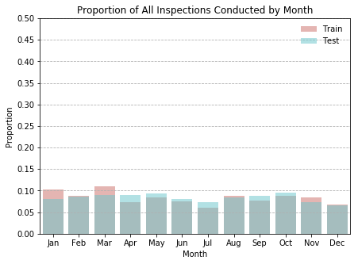

```python
p_insps_all_train = n_insps_month_train / n_insps_month_train.sum()
p_insps_all_test = n_insps_month_test / n_insps_month_test.sum()
# Plot proportion of all inspections conducted in each month
pal = sns.color_palette("hls", 2)
sns.barplot(MONTHS, p_insps_all_train, color=pal[0], alpha=0.5, label="Train")
sns.barplot(MONTHS, p_insps_all_test, color=pal[1], alpha=0.5, label="Test")
plt.xticks(MONTH_TICKS, MONTH_LABELS)
plt.ylim(0, 0.5)
plt.yticks(np.arange(0, 0.55, 0.05))
plt.grid(axis="y", linestyle="--")
plt.xlabel("Month")
plt.ylabel("Proportion")
plt.title("Proportion of All Inspections Conducted by Month")
plt.gcf().set_size_inches(7, 5)
plt.legend(frameon=False)
plt.show()
```

### Table 1. Summary of Violation Codes in Train and Test

- Sorted by violation code.
- V5 does not appear in the train set at all.
- V7 accounts for less than 0.5% of all violation codes issued in the train set.

Critical violation code descriptions referenced from [the City of Chicago Food Protection Division website](https://webapps1.cityofchicago.org/healthinspection/Code_Violations.jsp).

**V5: Likelihood of Infected Food Handler**

```
No person affected with or carrying any disease in a communicable form or afflicted with boils, infected wounds, sores, acute respiratory infection, or intestinal disorder shall work in any area of a food establishment in any capacity where there is a likelihood of that person contaminating food or food contact surfaces.
```

**V7: Adequate Washing of Utensils**

```
Hand washing of all tableware and drinking utensils shall be accomplished by the use of warm water at a temperature of 110°F to 120°F containing an adequate amount of detergent effective to remove grease and solids.
```

```python
vdf = pd.DataFrame()
vdf["Code"] = VIOLATION_LABELS
vdf["N(Train)"] = n_viols_month_train.sum(axis=0)
vdf["N(Test)"] = n_viols_month_test.sum(axis=0)
vdf["P(Train)"] = vdf["N(Train)"] / vdf["N(Train)"].sum()
vdf["P(Test)"] = vdf["N(Test)"] / vdf["N(Test)"].sum()
vdf["Rank(Train)"] = N_VIOLS - stat.rankdata(vdf["N(Train)"].values).astype(int) + 1
vdf["Rank(Test)"] = N_VIOLS - stat.rankdata(vdf["N(Test)"].values).astype(int) + 1
vdf.round(3)
```

|  | Code | N(Train) | N(Test) | P(Train) | P(Test) | Rank(Train) | Rank(Test) |
| --- | --- | --- | --- | --- | --- | --- | --- |
| 0 | V1 | 31 | 33 | 0.027 | 0.020 | 8 | 8 |
| 1 | V2 | 189 | 282 | 0.164 | 0.170 | 2 | 2 |
| 2 | V3 | 444 | 606 | 0.385 | 0.365 | 1 | 1 |
| 3 | V4 | 28 | 23 | 0.024 | 0.014 | 9 | 10 |
| 4 | V5 | 0 | 1 | 0.000 | 0.001 | 14 | 14 |
| 5 | V6 | 81 | 79 | 0.070 | 0.048 | 5 | 6 |
| 6 | V7 | 3 | 9 | 0.003 | 0.005 | 13 | 13 |
| 7 | V8 | 142 | 192 | 0.123 | 0.116 | 3 | 3 |
| 8 | V9 | 33 | 70 | 0.029 | 0.042 | 7 | 7 |
| 9 | V10 | 26 | 28 | 0.023 | 0.017 | 10 | 9 |
| 10 | V11 | 56 | 140 | 0.049 | 0.084 | 6 | 5 |
| 11 | V12 | 97 | 169 | 0.084 | 0.102 | 4 | 4 |
| 12 | V13 | 14 | 17 | 0.012 | 0.010 | 11 | 11 |
| 13 | V14 | 8 | 13 | 0.007 | 0.008 | 12 | 12 |

### Table 2. Frequency Ranking of Violation Codes in Train and Test

- Sorted by frequency in train set.
- Ranks for the top four violation codes match between train and test.
- Ranks for the bottom four violation codes match between train and test.

```python
vdf.sort_values(by=["Rank(Train)", "Rank(Test)"], ascending=[True, True]).round(3)
```

|  | Code | N(Train) | N(Test) | P(Train) | P(Test) | Rank(Train) | Rank(Test) |
| --- | --- | --- | --- | --- | --- | --- | --- |
| 2 | V3 | 444 | 606 | 0.385 | 0.365 | 1 | 1 |
| 1 | V2 | 189 | 282 | 0.164 | 0.170 | 2 | 2 |
| 7 | V8 | 142 | 192 | 0.123 | 0.116 | 3 | 3 |
| 11 | V12 | 97 | 169 | 0.084 | 0.102 | 4 | 4 |
| 5 | V6 | 81 | 79 | 0.070 | 0.048 | 5 | 6 |
| 10 | V11 | 56 | 140 | 0.049 | 0.084 | 6 | 5 |
| 8 | V9 | 33 | 70 | 0.029 | 0.042 | 7 | 7 |
| 0 | V1 | 31 | 33 | 0.027 | 0.020 | 8 | 8 |
| 3 | V4 | 28 | 23 | 0.024 | 0.014 | 9 | 10 |
| 9 | V10 | 26 | 28 | 0.023 | 0.017 | 10 | 9 |
| 12 | V13 | 14 | 17 | 0.012 | 0.010 | 11 | 11 |
| 13 | V14 | 8 | 13 | 0.007 | 0.008 | 12 | 12 |
| 6 | V7 | 3 | 9 | 0.003 | 0.005 | 13 | 13 |
| 4 | V5 | 0 | 1 | 0.000 | 0.001 | 14 | 14 |

## 1.5.2 Frequency of Violations by Month

Are certain violation codes more frequent in different months?

- Figure 3 will answer: Which month had the **highest fraction of all inspections** resulting in at least one critical violation found?
- Figure 4 will answer: Which month had the **highest rate of monthly inspections** resulting in at least one critical violation found?

### Figure 3. Proportion of All Inspections with Critical Found by Month

- Each series will sum to one.
- In the train set, October had the highest fraction of all inspections resulting in at least one critical violation found.
- In the test set, May and March had the highest fraction of all inspections resulting in at least one critical violation found.

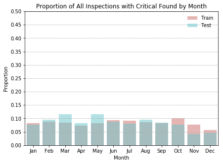

```python
p_found_all_train = n_found_month_train / n_found_month_train.sum()
p_found_all_test = n_found_month_test / n_found_month_test.sum()
pal = sns.color_palette("hls", 2)
sns.barplot(MONTHS, p_found_all_train, color=pal[0], alpha=0.5, label="Train")
sns.barplot(MONTHS, p_found_all_test, color=pal[1], alpha=0.5, label="Test")
plt.xticks(MONTH_TICKS, MONTH_LABELS)
plt.ylim(0, 0.5)
plt.yticks(np.arange(0, 0.55, 0.05))
plt.grid(axis="y", linestyle="--")
plt.xlabel("Month")
plt.ylabel("Proportion")
plt.title("Proportion of All Inspections with Critical Found by Month")
plt.gcf().set_size_inches(7, 5)
plt.legend(frameon=False)
plt.show()
```

### Figure 4. Proportion of Monthly Inspections with Critical Found by Month

- In the train set, July had the highest rate of monthly inspections resulting in at least one critical violation found.
- In the test set, March and May had the highest rate of monthly inspections resulting in at least one critical violation found.

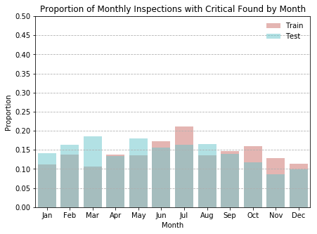

```python
# Plot proportion of critical found by month
pal = sns.color_palette("hls", 2)
sns.barplot(MONTHS, p_found_month_train, color=pal[0], alpha=0.5, label="Train")
sns.barplot(MONTHS, p_found_month_test, color=pal[1], alpha=0.5, label="Test")
plt.xticks(MONTH_TICKS, MONTH_LABELS)
plt.ylim(0, 0.5)
plt.yticks(np.arange(0, 0.55, 0.05))
plt.grid(axis="y", linestyle="--")
plt.xlabel("Month")
plt.ylabel("Proportion")
plt.title("Proportion of Monthly Inspections with Critical Found by Month")
plt.gcf().set_size_inches(7, 5)
plt.legend(frameon=False)
plt.show()
```

### Figure 5. Number of Violations Issued by Month

- Monthly totals for each code are stacked in order of decreasing frequency of the code in the train set.

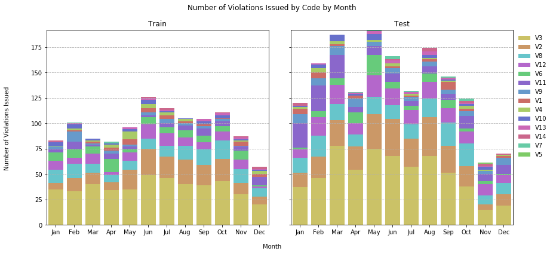

```python
fig, axes = plt.subplots(1, 2, sharex=False, sharey=True)
axes = axes.flatten()
viol_ids = vdf.sort_values(by=["N(Train)"], ascending=False).index.values
pal = sns.color_palette("hls", N_VIOLS)
bottom_train = np.zeros(len(MONTHS))
bottom_test = np.zeros(len(MONTHS))
for k, i in enumerate(viol_ids):
    viol = VIOLATION_LABELS[i]
    color = pal[i]
    ser_train = n_viols_month_train[:,i]
    ser_test = n_viols_month_test[:,i]
    if k > 0:
        bottom_idx = viol_ids[k - 1]
        bottom_train = bottom_train + n_viols_month_train[:,bottom_idx]
        bottom_test = bottom_test + n_viols_month_test[:,bottom_idx]
    sns.barplot(MONTHS, ser_train, bottom=bottom_train, color=color, label=viol, ax=axes[0])
    sns.barplot(MONTHS, ser_test, bottom=bottom_test, color=color, label=viol, ax=axes[1])
for ax, title in zip(axes, ["Train", "Test"]):
    ax.set_xticklabels(MONTH_LABELS)
    ax.grid(axis="y", linestyle="--")
    ax.set_title(title)
axes[0].legend(loc="upper left", frameon=False, bbox_to_anchor=(2.1, 1))
fig.text(0.5, 0.04, "Month", ha="center", va="center")
fig.text(0.06, 0.5, "Number of Violations Issued", ha="center", va="center", rotation="vertical")
fig.suptitle("Number of Violations Issued by Code by Month")
fig.set_size_inches(14, 6)
plt.subplots_adjust(hspace=0.5, wspace=0.1)
plt.show()
```

- Figure 6 will answer: Which month had the **highest fraction of all inspections** issuing the given code?
- Figures 7 and 8 will answer: Which month had the **highest rate of monthly inspections** issuing the given code?

### Figure 6. Proportion of All Violations with Violation Code by Month

- The series on each subplot will sum to one.

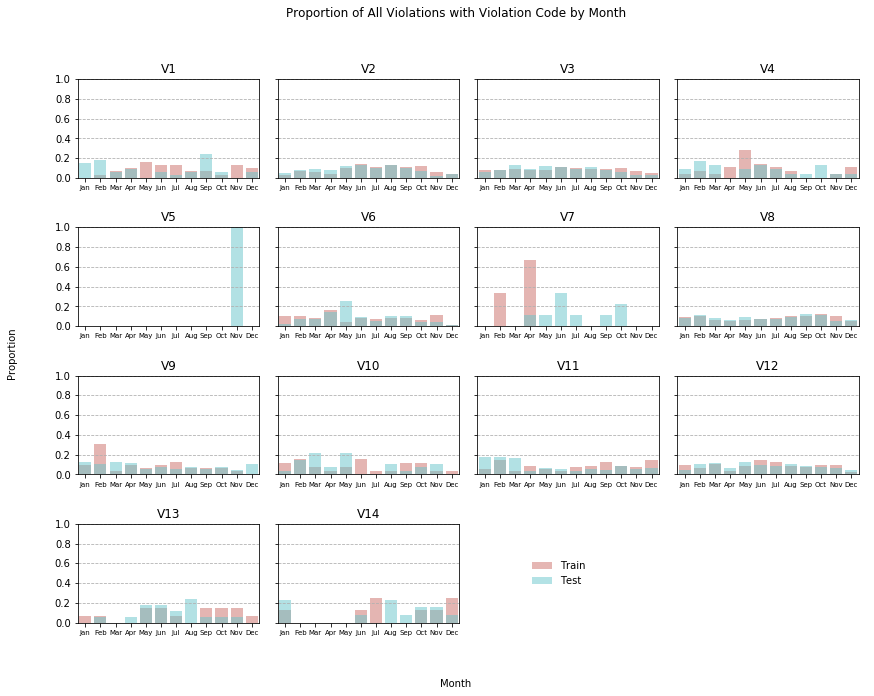

```python
fig, axes = plt.subplots(4, 4, sharex=False, sharey=True)
axes = axes.flatten()
pal = sns.color_palette("hls", 2)
for i, (viol, ax) in enumerate(zip(VIOLATION_LABELS, axes)):
    p_viols_all_train = np.zeros(len(MONTHS))
    p_viols_all_test = np.zeros(len(MONTHS))
    tot_train = n_viols_month_train[:,i].sum()
    tot_test = n_viols_month_test[:,i].sum()
    if tot_train > 0:
        p_viols_all_train = n_viols_month_train[:,i] / tot_train
    if tot_test > 0:
        p_viols_all_test = n_viols_month_test[:,i] / tot_test
    sns.barplot(MONTHS, p_viols_all_train, color=pal[0], alpha=0.5, ax=ax, label="Train")
    sns.barplot(MONTHS, p_viols_all_test, color=pal[1], alpha=0.5, ax=ax, label="Test")
    ax.set_xticklabels(MONTH_LABELS, fontsize=7)
    ax.set_ylim(0, 1)
    ax.set_yticks(np.arange(0, 1.2, 0.2))
    ax.grid(axis="y", linestyle="--")
    ax.set_title(viol)
axes[-2].axis("off")
axes[-1].axis("off")
axes[0].legend(loc="center", bbox_to_anchor=(2.65, -4), frameon=False)
fig.text(0.5, 0.04, "Month", ha="center", va="center")
fig.text(0.06, 0.5, "Proportion", ha="center", va="center", rotation="vertical")
fig.suptitle("Proportion of All Violations with Violation Code by Month")
fig.set_size_inches(14, 10)
plt.subplots_adjust(hspace=0.5, wspace=0.1)
plt.show()
```

### Figure 7. Proportion of Monthly Violations with Violation Code by Month

- The values for each month will sum to one.
- All subplot axes share the same range.

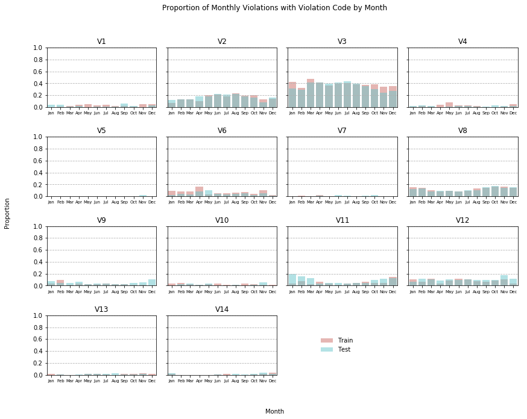

```python
# Plot proportion of each violation found by month
fig, axes = plt.subplots(4, 4, sharex=False, sharey=True)
axes = axes.flatten()
pal = sns.color_palette("hls", 2)
for i, (viol, ax) in enumerate(zip(VIOLATION_LABELS, axes)):
    sns.barplot(MONTHS, p_viols_month_train[:,i], color=pal[0], alpha=0.5, ax=ax, label="Train")
    sns.barplot(MONTHS, p_viols_month_test[:,i], color=pal[1], alpha=0.5, ax=ax, label="Test")
    ax.set_xticklabels(MONTH_LABELS, fontsize=7)
    ax.set_ylim(0, 1)
    ax.set_yticks(np.arange(0, 1.2, 0.2))
    ax.grid(axis="y", linestyle="--")
    ax.set_title(viol)
axes[-2].axis("off")
axes[-1].axis("off")
axes[0].legend(loc="center", bbox_to_anchor=(2.65, -4), frameon=False)
fig.text(0.5, 0.04, "Month", ha="center", va="center")
fig.text(0.06, 0.5, "Proportion", ha="center", va="center", rotation="vertical")
fig.suptitle("Proportion of Monthly Violations with Violation Code by Month")
fig.set_size_inches(14, 10)
plt.subplots_adjust(hspace=0.5, wspace=0.1)
plt.show()
```

### Figure 8. Proportion of Monthly Violations with Violation Code by Month (Different Axes)

- Same data as Figure 7.
- The values for each month will sum to one.
- Each subplot axis has a different range, to emphasize less frequent violation codes.

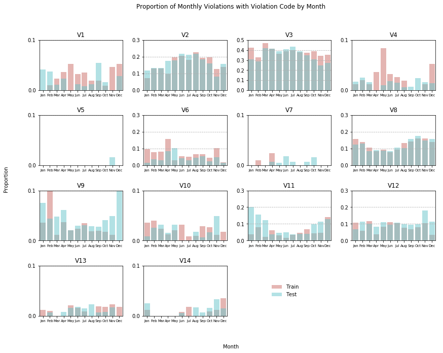

```python
# Plot proportion of each violation found by month
fig, axes = plt.subplots(4, 4, sharex=False, sharey=False)
axes = axes.flatten()
pal = sns.color_palette("hls", 2)
for i, (viol, ax) in enumerate(zip(VIOLATION_LABELS, axes)):
    sns.barplot(MONTHS, p_viols_month_train[:,i], color=pal[0], alpha=0.5, ax=ax, label="Train")
    sns.barplot(MONTHS, p_viols_month_test[:,i], color=pal[1], alpha=0.5, ax=ax, label="Test")
    max_p = np.vstack([p_viols_month_train[:,i], p_viols_month_test[:,i]]).max()
    max_y = math.ceil(10 * max_p) / 10
    ax.set_xticklabels(MONTH_LABELS, fontsize=7)
    ax.set_ylim(0, max_y)
    ax.set_yticks(np.arange(0, max_y + 0.1, 0.1))
    ax.grid(axis="y", linestyle="--")
    ax.set_title(viol)
axes[-2].axis("off")
axes[-1].axis("off")
axes[0].legend(loc="center", bbox_to_anchor=(2.95, -4), frameon=False)
fig.text(0.5, 0.04, "Month", ha="center", va="center")
fig.text(0.06, 0.5, "Proportion", ha="center", va="center", rotation="vertical")
fig.suptitle("Proportion of Monthly Violations with Violation Code by Month")
fig.set_size_inches(14, 10)
plt.subplots_adjust(hspace=0.5, wspace=0.25)
plt.show()
```

## 1.5.3 City Model Scheduling

How does the City model schedule a full year of inspections?

### Table 3. Confusion Matrix for City Model Predictions on Test Set

```python
from datetime import datetime
from research.strings import PREDICTORS
from research.evaluation import evaluate_model
from research.metrics import to_inspection_daynum, compare_metrics, get_days_by_score


days_train = to_inspection_daynum(df_train[DATE])
days_test = to_inspection_daynum(df_test[DATE])
X_train = df_train[PREDICTORS]
X_test = df_test[PREDICTORS]
y_train = df_train[TARGET]
y_test = df_test[TARGET]

city = pickle.load(open("models/sklearn-glm.pkl", "rb"))
city_scores = city.predict_proba(X_test)[:,1]
city_pred = city.predict(X_test)
evaluate_model(y_test, city_pred)
```

```
F1 Score = 0.03532
Precision = 0.47727
Recall = 0.01834
```

|  | Predicted + | Predicted - |
| --- | --- | --- |
| Actual + | 21 | 1124 |
| Actual - | 23 | 6686 |

### Figure 9. City Model Performance According to City Metrics on Test Set

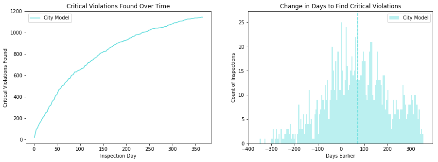

|  | Model | First Half | Mean Change | Std. Change |
| --- | --- | --- | --- | --- |
| 0 | City Model | 0.784 | 72.08 | 140.254 |

```python
compare_metrics(y_test, days_test, [("City Model", city_scores)])
```

```python
def date_df_by_score(df_data, crit_mat, scores):
    SECONDS = 60 * 60 * 24
    idf = pd.DataFrame({
        "Inspection_ID": df_data[INSPECTION_ID],
        "new_inspection_date": get_days_by_score(df_data[DATE], scores),
        "score": scores,
        "criticalFound": df_data[TARGET].astype(int)
    })
    calendar_date = idf["new_inspection_date"].apply(lambda d: datetime.fromtimestamp((d + 1) * SECONDS))
    idf["year"] = calendar_date.apply(lambda d: d.strftime("%Y"))
    idf["month"] = calendar_date.apply(lambda d: d.strftime("%m"))
    idf = idf.set_index(INSPECTION_ID).join(crit_mat.set_index(INSPECTION_ID))
    idf = idf.reset_index()
    return idf
```

```python
# Group violations by month for City model
df_city = date_df_by_score(df_test, crit_mat, city_scores)
model_found, model_viols = group_crits_month(df_city)
n_insps_month_model, n_found_month_model, p_found_month_model = model_found
n_viols_month_model, n_totals_month_model, p_viols_month_model = model_viols
p_insps_all_model = n_insps_month_model / n_insps_month_model.sum()
p_found_all_model = n_found_month_model / n_found_month_model.sum()
```

### Figure 10. Number of Inspections Conducted by Month

- City Model schedule should have exactly the same number of inspections per month as the original test set.

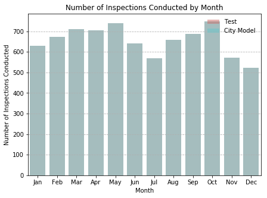

```python
# Recreate figure 1
pal = sns.color_palette("hls", 2)
sns.barplot(MONTHS, n_insps_month_test, color=pal[0], alpha=0.5, label="Test")
sns.barplot(MONTHS, n_insps_month_model, color=pal[1], alpha=0.5, label="City Model")
plt.xticks(MONTH_TICKS, MONTH_LABELS)
plt.grid(axis="y", linestyle="--")
plt.xlabel("Month")
plt.ylabel("Number of Inspections Conducted")
plt.title("Number of Inspections Conducted by Month")
plt.gcf().set_size_inches(7, 5)
plt.legend(frameon=False)
plt.show()
```

- Figure 11 will answer: Which month had the **highest fraction of all inspections** resulting in at least one critical violation found?
- Figure 12 will answer: Which month had the **highest rate of monthly inspections** resulting in at least one critical violation found?

### Figure 11. Proportion of All Inspections with Critical Found by Month

- Remember that the test set starts in April and continues through the year to March.
- As expected, the first month of the model schedule has the highest fraction of all inspections resulting in at least one critical violation found and the fraction generally decreases with each successive month.

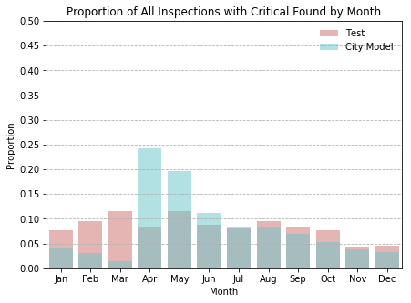

```python
# Recreate figure 3
pal = sns.color_palette("hls", 2)
sns.barplot(MONTHS, p_found_all_test, color=pal[0], alpha=0.5, label="Test")
sns.barplot(MONTHS, p_found_all_model, color=pal[1], alpha=0.5, label="City Model")
plt.xticks(MONTH_TICKS, MONTH_LABELS)
plt.ylim(0, 0.5)
plt.yticks(np.arange(0, 0.55, 0.05))
plt.grid(axis="y", linestyle="--")
plt.xlabel("Month")
plt.ylabel("Proportion")
plt.title("Proportion of All Inspections with Critical Found by Month")
plt.gcf().set_size_inches(7, 5)
plt.legend(frameon=False)
plt.show()
```

### Figure 12. Proportion of Monthly Inspections with Critical Found by Month

- Remember that the test set starts in April and continues through the year to March.
- As expected, the first month of the model schedule has the highest rate of monthly inspections resulting in at least one critical violation found and the rate generally decreases with each successive month.

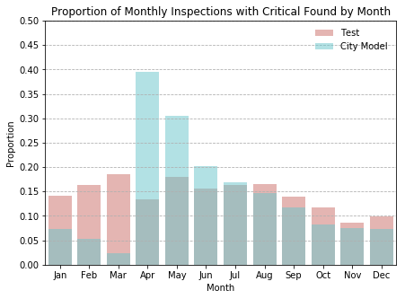

```python
# Recreate figure 4
pal = sns.color_palette("hls", 2)
sns.barplot(MONTHS, p_found_month_test, color=pal[0], alpha=0.5, label="Test")
sns.barplot(MONTHS, p_found_month_model, color=pal[1], alpha=0.5, label="City Model")
plt.xticks(MONTH_TICKS, MONTH_LABELS)
plt.ylim(0, 0.5)
plt.yticks(np.arange(0, 0.55, 0.05))
plt.grid(axis="y", linestyle="--")
plt.xlabel("Month")
plt.ylabel("Proportion")
plt.title("Proportion of Monthly Inspections with Critical Found by Month")
plt.gcf().set_size_inches(7, 5)
plt.legend(frameon=False)
plt.show()
```

### Figure 13. Number of Violations Issued by Month

- Remember that the test set starts in April and continues through the year to March.
- Monthly totals for each code are stacked in order of decreasing frequency of the code in the train set.

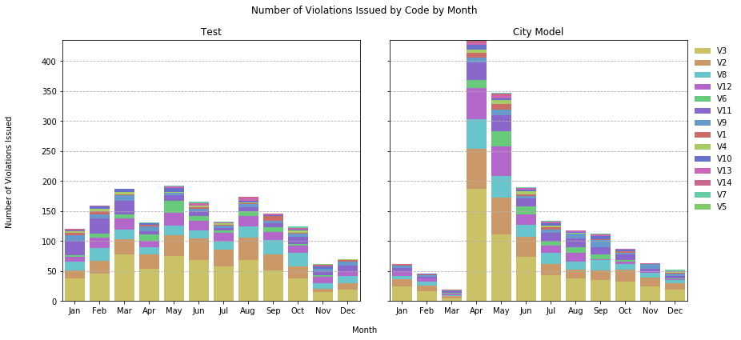

```python
# Recreate figure 5
fig, axes = plt.subplots(1, 2, sharex=False, sharey=True)
axes = axes.flatten()
viol_ids = vdf.sort_values(by=["N(Train)"], ascending=False).index.values
pal = sns.color_palette("hls", N_VIOLS)
bottom_model = np.zeros(len(MONTHS))
bottom_test = np.zeros(len(MONTHS))
for k, i in enumerate(viol_ids):
    viol = VIOLATION_LABELS[i]
    color = pal[i]
    ser_model = n_viols_month_model[:,i]
    ser_test = n_viols_month_test[:,i]
    if k > 0:
        bottom_idx = viol_ids[k - 1]
        bottom_model = bottom_model + n_viols_month_model[:,bottom_idx]
        bottom_test = bottom_test + n_viols_month_test[:,bottom_idx]
    sns.barplot(MONTHS, ser_test, bottom=bottom_test, color=color, label=viol, ax=axes[0])
    sns.barplot(MONTHS, ser_model, bottom=bottom_model, color=color, label=viol, ax=axes[1])
for ax, title in zip(axes, ["Test", "City Model"]):
    ax.set_xticklabels(MONTH_LABELS)
    ax.grid(axis="y", linestyle="--")
    ax.set_title(title)
axes[0].legend(loc="upper left", frameon=False, bbox_to_anchor=(2.1, 1))
fig.text(0.5, 0.04, "Month", ha="center", va="center")
fig.text(0.06, 0.5, "Number of Violations Issued", ha="center", va="center", rotation="vertical")
fig.suptitle("Number of Violations Issued by Code by Month")
fig.set_size_inches(14, 6)
plt.subplots_adjust(hspace=0.5, wspace=0.1)
plt.show()
```

- Figure 14 will answer: Which month had the **highest fraction of all inspections** issuing the given code?
- Figure 15 will answer: Which month had the **highest rate of monthly inspections** issuing the given code?

### Figure 14. Proportion of All Violations with Violation Code by Month

- Remember that the test set starts in April and continues through the year to March.
- The series on each subplot will sum to one.

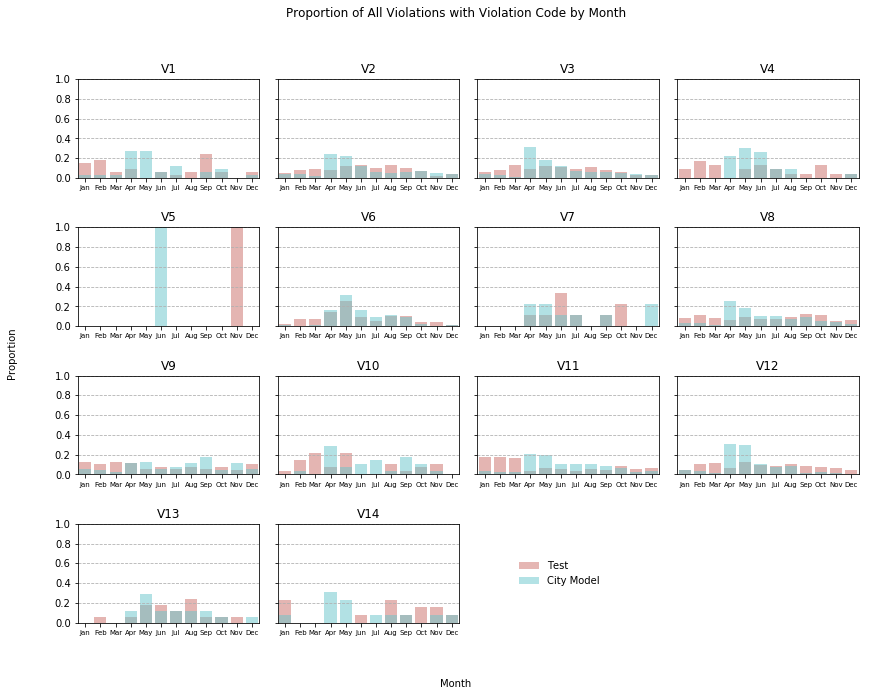

```python
# Recreate figure 6
fig, axes = plt.subplots(4, 4, sharex=False, sharey=True)
axes = axes.flatten()
pal = sns.color_palette("hls", 2)
for i, (viol, ax) in enumerate(zip(VIOLATION_LABELS, axes)):
    p_viols_all_model = np.zeros(len(MONTHS))
    p_viols_all_test = np.zeros(len(MONTHS))
    tot_model = n_viols_month_model[:,i].sum()
    tot_test = n_viols_month_test[:,i].sum()
    if tot_model > 0:
        p_viols_all_model = n_viols_month_model[:,i] / tot_model
    if tot_test > 0:
        p_viols_all_test = n_viols_month_test[:,i] / tot_test
    sns.barplot(MONTHS, p_viols_all_test, color=pal[0], alpha=0.5, ax=ax, label="Test")
    sns.barplot(MONTHS, p_viols_all_model, color=pal[1], alpha=0.5, ax=ax, label="City Model")
    ax.set_xticklabels(MONTH_LABELS, fontsize=7)
    ax.set_ylim(0, 1)
    ax.set_yticks(np.arange(0, 1.2, 0.2))
    ax.grid(axis="y", linestyle="--")
    ax.set_title(viol)
axes[-2].axis("off")
axes[-1].axis("off")
axes[0].legend(loc="center", bbox_to_anchor=(2.65, -4), frameon=False)
fig.text(0.5, 0.04, "Month", ha="center", va="center")
fig.text(0.06, 0.5, "Proportion", ha="center", va="center", rotation="vertical")
fig.suptitle("Proportion of All Violations with Violation Code by Month")
fig.set_size_inches(14, 10)
plt.subplots_adjust(hspace=0.5, wspace=0.1)
plt.show()
```

### Figure 15. Proportion of Monthly Violations with Violation Code by Month (Different Axes)

- Different data from Figure 14.
- Remember that the test set starts in April and continues through the year to March.
- The values for each month will sum to one.
- Each subplot axis has a different range, to emphasize less frequent violation codes.

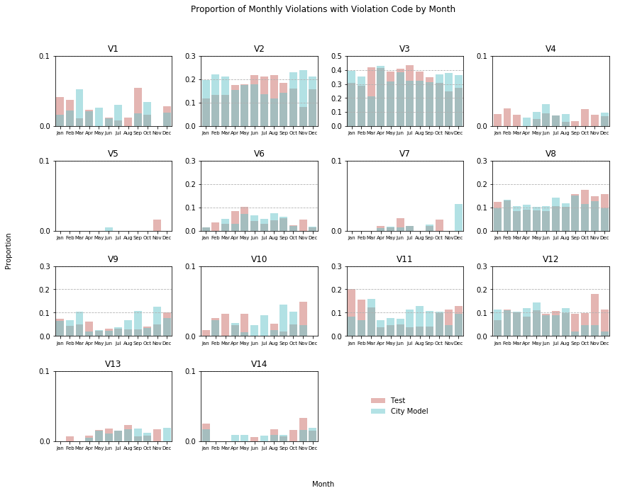

```python
# Recreate figure 8
fig, axes = plt.subplots(4, 4, sharex=False, sharey=False)
axes = axes.flatten()
pal = sns.color_palette("hls", 2)
for i, (viol, ax) in enumerate(zip(VIOLATION_LABELS, axes)):
    sns.barplot(MONTHS, p_viols_month_test[:,i], color=pal[0], alpha=0.5, ax=ax, label="Test")
    sns.barplot(MONTHS, p_viols_month_model[:,i], color=pal[1], alpha=0.5, ax=ax, label="City Model")
    max_p = np.vstack([p_viols_month_model[:,i], p_viols_month_test[:,i]]).max()
    max_y = math.ceil(10 * max_p) / 10
    ax.set_xticklabels(MONTH_LABELS, fontsize=7)
    ax.set_ylim(0, max_y)
    ax.set_yticks(np.arange(0, max_y + 0.1, 0.1))
    ax.grid(axis="y", linestyle="--")
    ax.set_title(viol)
axes[-2].axis("off")
axes[-1].axis("off")
axes[0].legend(loc="center", bbox_to_anchor=(2.95, -4), frameon=False)
fig.text(0.5, 0.04, "Month", ha="center", va="center")
fig.text(0.06, 0.5, "Proportion", ha="center", va="center", rotation="vertical")
fig.suptitle("Proportion of Monthly Violations with Violation Code by Month")
fig.set_size_inches(14, 10)
plt.subplots_adjust(hspace=0.5, wspace=0.25)
plt.show()
```